# Análise dos dados faltantes

Agatha Rodrigues

20/06/2021

# Pacotes

```r
loadlibrary <- function(x) {
  if (!require(x, character.only = TRUE)) {
    install.packages(x, dependencies = T)
    if (!require(x, character.only = TRUE))
      stop("Package not found")
  }
}

packages <- c(
  "tidyverse",
  "readxl",
  "janitor",
  "skimr",
  "lubridate",
  "summarytools",
  "magrittr",
  "knitr",
  "esquisse",
  "viridis",
  "cowplot",
  "tidyr",
  "reshape2",
  "VIM",
  "mice",
  "VGAM",
  "nlme",
  "visreg",
  "lme4",
  "glmnet",
  "leaps",
  "glmmLasso",
  "glmmTMB",
  "mgcv",
  "writexl", "tidyverse", "readxl", "janitor",
  "skimr", "lubridate", "summarytools",
  "magrittr", "knitr", "esquisse",
  "viridis",
  "cowplot", "tidyr", "reshape2", "VIM", "mice",
  "longitudinalData"
)
lapply(packages, loadlibrary)
```

Funções:

```r
getmode <- function(v) {
   which.max(tabulate(v))
}
```

# Dados

```r
dados <- read_excel("Base_TocoColoPerinatal.xls")
# View(dados)

dados <- clean_names(dados)
names(dados)
```

```
##  [1] "id"           "indic_aval"   "ig_aval"      "medida_colo"  "num_contra"
##  [6] "ovulos"       "corion"       "im"           "tescola"      "cor_branco"
## [11] "peso_pre"     "alt"          "imc"          "gesta"        "para"
## [16] "a"            "ind_ap"       "hv_tabagismo" "hv_alcool"    "hv_drogas"
## [21] "igp_parto"
```

```r
#Verifica a existência de valores que não deveriam existir nas
#variáveis ajustadas à essa função.

verifica_erro <- function(v){

  if(v %in% "ovulos"){
    any(as.data.frame(dados)$v != 1 & as.data.frame(dados)$v != 2)
  } else if(v %in% "corion"){
    any(as.data.frame(dados)$v != 1 & as.data.frame(dados)$v != 2)
  } else if(v != "ovulos"& v != "corion")
    any(as.data.frame(dados)$v != 0 & as.data.frame(dados)$v != 1)
}

list_var_names <- c("ovulos", "corion", "cor_branco", "ind_ap",
                    "hv_tabagismo", "hv_alcool", "hv_drogas")


sapply(list_var_names, verifica_erro)
```

```
##       ovulos       corion   cor_branco       ind_ap hv_tabagismo    hv_alcool
##        FALSE        FALSE        FALSE        FALSE        FALSE        FALSE
##    hv_drogas
##        FALSE
```

```r
dados$medida_colo[dados$medida_colo == 0] <- NA


dados$ovulos <- fct_recode(as.factor(dados$ovulos),
                           placebo = "1", progesterona = "2")
dados$corion <- fct_recode(as.factor(dados$corion),
                           "monocoriônica" = "1",
                           "dicoriônica" = "2")
dados[c("cor_branco",
        "ind_ap",
        "hv_tabagismo",
        "hv_alcool",
        "hv_drogas")] <-
  lapply(dados[c("cor_branco",
                 "ind_ap",
                 "hv_tabagismo",
                 "hv_alcool",
                 "hv_drogas")],
         factor,
         levels = c(0,1),
         labels = c("não","sim"))

dados$ig_aval_sem <- trunc(dados$ig_aval)
```

## Variáveis fixas

Vamos primeiro analisar as variáveis fixas.

```r
dados_fixas <- dados %>%
  filter(indic_aval == 1)  %>%
  select(-indic_aval,
         -ig_aval,
         -medida_colo,
         -num_contra,
         -imc,
         -ig_aval_sem,
         -imc)
```

Vi que há 2 dados faltantes em aborto (`a`), mas não há em gesta e nem em partos.

Uma coisa para mudar na base: `a` (aborto) é igual a gestações menos parto e menos 1.

```r
dados_fixas$a[is.na(dados_fixas$a)] <- dados_fixas$gesta[is.na(dados_fixas$a)] -  dados_fixas$para[is.na(dados_fixas$a)] - 1
```

Vamos criar uma variável auxiliar para ver o número de gestações ao considerar partos mais abortos e mais um (a gestação atual).

```r
aux <- dados_fixas$para + dados_fixas$a + 1
```

Mas note que para alguns casos (7 casos) o número de gestações (`gesta`) não é igual à variável auxiliar. Corrigimos isso no que segue:

```r
dados_fixas <- dados_fixas %>%
  mutate(gesta = para + a + 1)
```

Vamos agora ver as variáveis fixas que tem valores ausentes.

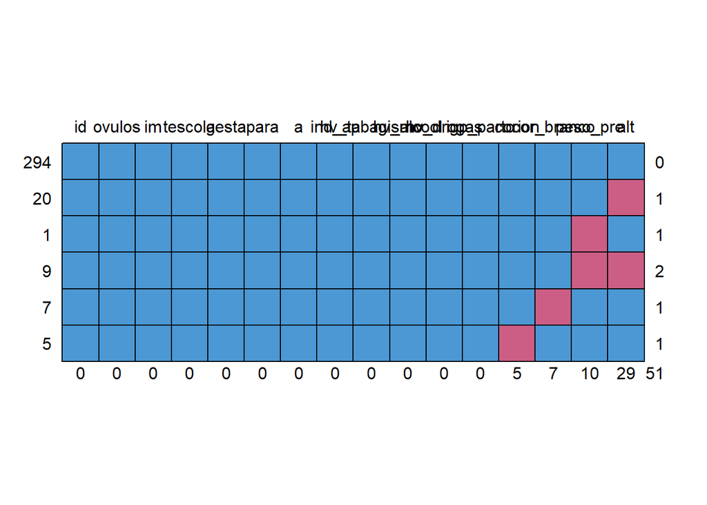

```
##     id ovulos im tescola gesta para a ind_ap hv_tabagismo hv_alcool hv_drogas
## 294  1      1  1       1     1    1 1      1            1         1         1
## 20   1      1  1       1     1    1 1      1            1         1         1
## 1    1      1  1       1     1    1 1      1            1         1         1
## 9    1      1  1       1     1    1 1      1            1         1         1
## 7    1      1  1       1     1    1 1      1            1         1         1
## 5    1      1  1       1     1    1 1      1            1         1         1
##      0      0  0       0     0    0 0      0            0         0         0
##     igp_parto corion cor_branco peso_pre alt
## 294         1      1          1        1   1  0
## 20          1      1          1        1   0  1
## 1           1      1          1        0   1  1
## 9           1      1          1        0   0  2
## 7           1      1          0        1   1  1
## 5           1      0          1        1   1  1
##             0      5          7       10  29 51
```

```r
md.pattern(dados_fixas)
```

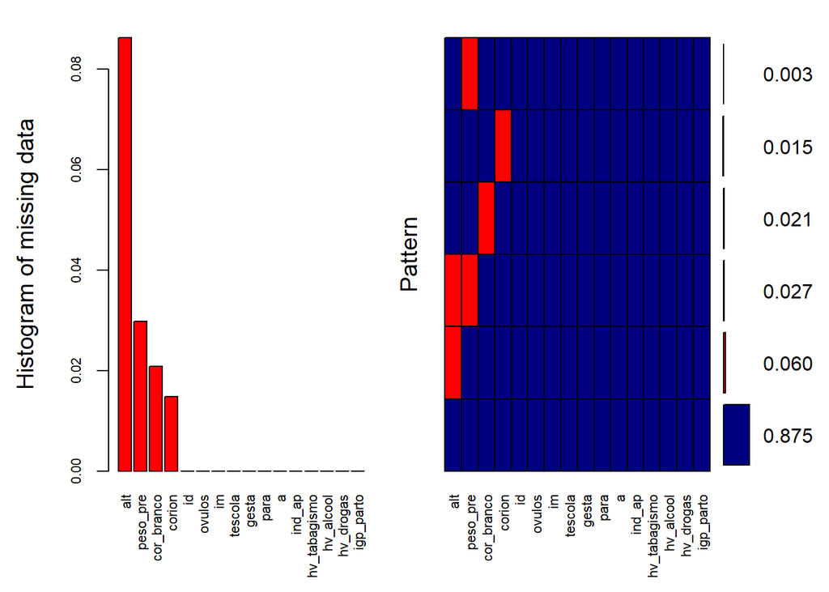

```
##
##  Variables sorted by number of missings:
##      Variable      Count
##           alt 0.08630952
##      peso_pre 0.02976190
##    cor_branco 0.02083333
##        corion 0.01488095
##            id 0.00000000
##        ovulos 0.00000000
##            im 0.00000000
##       tescola 0.00000000
##         gesta 0.00000000
##          para 0.00000000
##             a 0.00000000
##        ind_ap 0.00000000
##  hv_tabagismo 0.00000000
##     hv_alcool 0.00000000
##     hv_drogas 0.00000000
##     igp_parto 0.00000000
```

```r
aggr_plot <-
  aggr(
    dados_fixas,
    col = c('navyblue', 'red'),
    numbers = TRUE,
    sortVars = TRUE,
    labels = names(dados_fixas),
    cex.axis = .7,
    gap = 3,
    ylab = c("Histogram of missing data", "Pattern")
  )
```

Usamos o método MICE para imputar os dados faltantes para as variáveis fixas.

```r
mice_dados_fixas <-
  mice(
    dados_fixas,
    m = 10,
    maxit = 50,
    meth = 'pmm',
    seed = 500
  )
# summary(mice_dados_fixas)
```

```r
aux_dados_fixas <- complete(mice_dados_fixas, "all",  mild = TRUE)

sem <- c("corion", "cor_branco", "peso_pre",
         "alt")
nrep <- c("1", "2", "3", "4", "5", "6", "7", "8", "9", "10")

aux <- matrix(0, nrow = dim(dados_fixas)[1], ncol = length(sem))
for (i in 1:2) {
  out <- aux_dados_fixas[[nrep[1]]][[sem[i]]]
  for (j in 2:length(nrep)) {
    out <- cbind(out, aux_dados_fixas[[nrep[j]]][[sem[i]]])
  }
  for (k in 1:dim(dados_fixas)[1]) {
    aux[k, i] <- getmode(out[k, ])
  }
}
for (i in 3:4) {
  out <- matrix(0, ncol = 1, nrow = dim(dados_fixas)[1])
  for (j in 1:length(nrep)) {
    out <- aux_dados_fixas[[nrep[j]]][[sem[i]]] + out
  }
  aux[, i] <- out / length(nrep)
}

dados_fixas_completo <-
  data.frame(
    id = aux_dados_fixas[["1"]][["id"]],
    ovulos = aux_dados_fixas[["1"]][["ovulos"]],
    corion = aux[, 1],
    im = aux_dados_fixas[["1"]][["im"]],
    tescola = aux_dados_fixas[["1"]][["tescola"]],
    cor_branco = aux[, 2],
    peso_pre = aux[, 3],
    alt = aux[, 4],
    gesta = aux_dados_fixas[["1"]][["gesta"]],
    para = aux_dados_fixas[["1"]][["para"]],
    a = aux_dados_fixas[["1"]][["a"]],
    ind_ap = aux_dados_fixas[["1"]][["ind_ap"]],
    hv_tabagismo = aux_dados_fixas[["1"]][["hv_tabagismo"]],
    hv_alcool = aux_dados_fixas[["1"]][["hv_alcool"]],
    hv_drogas = aux_dados_fixas[["1"]][["hv_drogas"]],
    igp_parto = aux_dados_fixas[["1"]][["igp_parto"]]
  )

dados_fixas_completo$corion <-
  fct_recode(
    as.factor(dados_fixas_completo$corion),
    "monocoriônica" = "1",
    "dicoriônica" = "2"
  )

dados_fixas_completo$cor_branco <-
  fct_recode(as.factor(dados_fixas_completo$cor_branco),
             "não" = "1",
             "sim" = "2")

dados_fixas_completo <- dados_fixas_completo %>%
  mutate(imc = peso_pre / (alt ^ 2))
```

Pronto! Agora as variáveis fixas já foram devidamente imputadas e o objeto com a imputação é o `dados_fixas_completo`.

Agora vamos criar uma base concatenando as variáveis longitudinais e também as variáveis fixas, mas agora com a imputação.

```r
dados_long <- dados %>%
  select(id, indic_aval, ig_aval, ig_aval_sem, medida_colo, num_contra)
```

```r
dados_obs <- full_join(dados_long, dados_fixas_completo, by="id")
```

## Concatenação nas semanas

```r
dados1 <- dados_obs %>%
  select(id, ig_aval_sem, igp_parto, medida_colo) %>%
  spread(key = ig_aval_sem, value = medida_colo)
```

```r
dadosa <- data.frame(id=unique(dados_obs$id))
dadosa$s24 <- aggregate(dados1$"24",
                        by=list(Category=dados1$id),
                        FUN=function(x) mean(x, na.rm = TRUE))$x
dadosa$s25 <- aggregate(dados1$"25",
                        by=list(Category=dados1$id),
                        FUN=function(x) mean(x, na.rm = TRUE))$x
dadosa$s26 <- aggregate(dados1$"26",
                        by=list(Category=dados1$id),
                        FUN=function(x) mean(x, na.rm = TRUE))$x
dadosa$s27 <- aggregate(dados1$"27",
                        by=list(Category=dados1$id),
                        FUN=function(x) mean(x, na.rm = TRUE))$x
dadosa$s28 <- aggregate(dados1$"28",
                        by=list(Category=dados1$id),
                        FUN=function(x) mean(x, na.rm = TRUE))$x
dadosa$s29 <- aggregate(dados1$"29",
                        by=list(Category=dados1$id),
                        FUN=function(x) mean(x, na.rm = TRUE))$x
dadosa$s30 <- aggregate(dados1$"30",
                        by=list(Category=dados1$id),
                        FUN=function(x) mean(x, na.rm = TRUE))$x
dadosa$s31 <- aggregate(dados1$"31",
                        by=list(Category=dados1$id),
                        FUN=function(x) mean(x, na.rm = TRUE))$x
dadosa$s32 <- aggregate(dados1$"32",
                        by=list(Category=dados1$id),
                        FUN=function(x) mean(x, na.rm = TRUE))$x
dadosa$s33 <- aggregate(dados1$"33",
                        by=list(Category=dados1$id),
                        FUN=function(x) mean(x, na.rm = TRUE))$x
dadosa$s34 <- aggregate(dados1$"34",
                        by=list(Category=dados1$id),
                        FUN=function(x) mean(x, na.rm = TRUE))$x
dadosa$ig_parto <- aggregate(dados1$igp_parto,
                             by=list(Category=dados1$id),
                             FUN=function(x) mean(x, na.rm = TRUE))$x
dadosa[is.na(dadosa)] <- NA

## Concatenar de 2 em 2 semanas (como foi observado na pratica)
colo_aux <- matrix(0, nrow = dim(dadosa)[1], ncol = 8)

colo_aux[,1] <- dadosa[,1]
colo_aux[,2] <- apply(dadosa[ ,2:4], 1,
                      function(x) mean(x, na.rm=TRUE))
colo_aux[,3] <- apply(dadosa[ ,5:6], 1,
                      function(x) mean(x, na.rm=TRUE))
colo_aux[,4] <- apply(dadosa[ ,7:8], 1,
                      function(x) mean(x, na.rm=TRUE))
colo_aux[,5] <- apply(dadosa[ ,9:10], 1,
                      function(x) mean(x, na.rm=TRUE))
colo_aux[,6] <- apply(dadosa[ ,11:12], 1,
                      function(x) mean(x, na.rm=TRUE))
colo_aux[,7] <- apply(colo_aux[,2:6], 1,
                      function(x) sum(is.na(x)))
colo_aux[,8] <- dadosa$ig_parto

# contagem de NA's
table(colo_aux[,7])
```

```
##
##   1   2   3   4   5
##  70 121  72  42  31
```

```r
## Concatenar num_contra
dados2 <- dados_obs %>%
  select(id, ig_aval_sem, igp_parto, num_contra) %>%
  spread(key = ig_aval_sem, value = num_contra)

dadosb <- data.frame(id=unique(dados_obs$id))
dadosb$s24 <- aggregate(dados2$"24",
                        by=list(Category=dados2$id),
                        FUN=function(x) mean(x, na.rm = TRUE))$x
dadosb$s25 <- aggregate(dados2$"25",
                        by=list(Category=dados2$id),
                        FUN=function(x) mean(x, na.rm = TRUE))$x
dadosb$s26 <- aggregate(dados2$"26",
                        by=list(Category=dados2$id),
                        FUN=function(x) mean(x, na.rm = TRUE))$x
dadosb$s27 <- aggregate(dados2$"27",
                        by=list(Category=dados2$id),
                        FUN=function(x) mean(x, na.rm = TRUE))$x
dadosb$s28 <- aggregate(dados2$"28",
                        by=list(Category=dados2$id),
                        FUN=function(x) mean(x, na.rm = TRUE))$x
dadosb$s29 <- aggregate(dados2$"29",
                        by=list(Category=dados2$id),
                        FUN=function(x) mean(x, na.rm = TRUE))$x
dadosb$s30 <- aggregate(dados2$"30",
                        by=list(Category=dados2$id),
                        FUN=function(x) mean(x, na.rm = TRUE))$x
dadosb$s31 <- aggregate(dados2$"31",
                        by=list(Category=dados2$id),
                        FUN=function(x) mean(x, na.rm = TRUE))$x
dadosb$s32 <- aggregate(dados2$"32",
                        by=list(Category=dados2$id),
                        FUN=function(x) mean(x, na.rm = TRUE))$x
dadosb$s33 <- aggregate(dados2$"33",
                        by=list(Category=dados2$id),
                        FUN=function(x) mean(x, na.rm = TRUE))$x
dadosb$s34 <- aggregate(dados2$"34",
                        by=list(Category=dados2$id),
                        FUN=function(x) mean(x, na.rm = TRUE))$x
dadosb$ig_parto <- aggregate(dados2$igp_parto,
                             by=list(Category=dados2$id),
                             FUN=function(x) mean(x, na.rm = TRUE))$x
dadosb[is.na(dadosb)] <- NA

## Concatenar de 2 em 2 semanas
contra_aux <- matrix(0, nrow = dim(dadosb)[1], ncol = 8)
contra_aux[,1] <- dadosb[,1]
contra_aux[,2] <- apply(dadosb[ ,2:4], 1,
                        function(x) mean(x, na.rm=TRUE))
contra_aux[,3] <- apply(dadosb[ ,5:6], 1,
                        function(x) mean(x, na.rm=TRUE))
contra_aux[,4] <- apply(dadosb[ ,7:8], 1,
                        function(x) mean(x, na.rm=TRUE))
contra_aux[,5] <- apply(dadosb[ ,9:10], 1,
                        function(x) mean(x, na.rm=TRUE))
contra_aux[,6] <- apply(dadosb[ ,11:12], 1,
                        function(x) mean(x, na.rm=TRUE))
contra_aux[,7] <- apply(contra_aux[,2:6], 1,
                        function(x) sum(is.na(x)))
contra_aux[,8] <- dadosb$ig_parto

# Contagem de NA's
table(contra_aux[,7])
```

```
##
##   0   1   2   3   4
##   8 102 120  70  36
```

```r
## vamos só considerar aqueles casos com pelo menos 2 avaliações no
#pré-natal

colo_novo <- colo_aux[colo_aux[, 7] < 4,]
contra_novo <- contra_aux[contra_aux[, 7] < 4, ]

dados_colo <- data.frame(id = colo_novo[,1], sem24_26 = colo_novo[,2], sem27_28 = colo_novo[,3], sem29_30 = colo_novo[,4],
                         sem31_32 = colo_novo[,5], sem33_34 = colo_novo[,6],
                         ig_parto = colo_novo[,8])

dados_colo[is.na(dados_colo)] <- NA


dados_num_contra <- data.frame(id = contra_novo[,1], sem24_26 = contra_novo[,2],
                              sem27_28 = contra_novo[,3], sem29_30 = contra_novo[,4],
                               sem31_32 = contra_novo[,5], sem33_34 = contra_novo[,6],
                         ig_parto = contra_novo[,8])
dados_num_contra[is.na(dados_num_contra)] <- NA
```

# Imputação para medida do colo

Agora vamos realizar nova análise de dados faltantes.

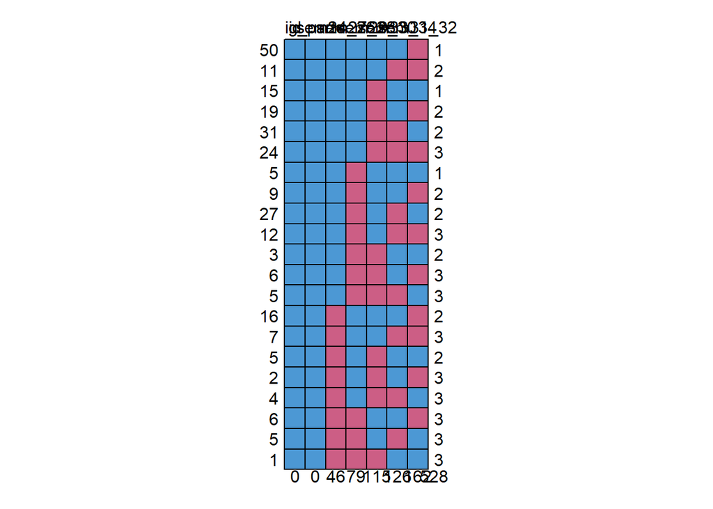

```
##    id ig_parto sem24_26 sem27_28 sem29_30 sem33_34 sem31_32
## 50  1        1        1        1        1        1        0   1
## 11  1        1        1        1        1        0        0   2
## 15  1        1        1        1        0        1        1   1
## 19  1        1        1        1        0        1        0   2
## 31  1        1        1        1        0        0        1   2
## 24  1        1        1        1        0        0        0   3
## 5   1        1        1        0        1        1        1   1
## 9   1        1        1        0        1        1        0   2
## 27  1        1        1        0        1        0        1   2
## 12  1        1        1        0        1        0        0   3
## 3   1        1        1        0        0        1        1   2
## 6   1        1        1        0        0        1        0   3
## 5   1        1        1        0        0        0        1   3
## 16  1        1        0        1        1        1        0   2
## 7   1        1        0        1        1        0        0   3
## 5   1        1        0        1        0        1        1   2
## 2   1        1        0        1        0        1        0   3
## 4   1        1        0        1        0        0        1   3
## 6   1        1        0        0        1        1        0   3
## 5   1        1        0        0        1        0        1   3
## 1   1        1        0        0        0        1        1   3
##     0        0       46       79      115      126      162 528
```

```r
md.pattern(dados_colo)
```

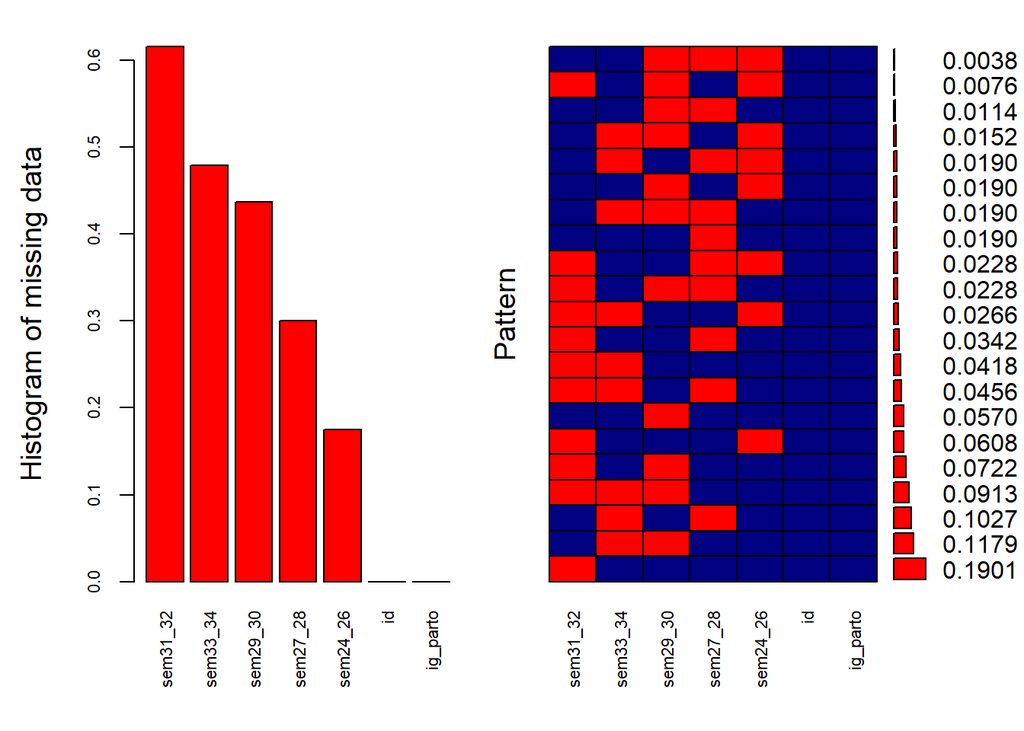

```
##
##  Variables sorted by number of missings:
##  Variable     Count
##  sem31_32 0.6159696
##  sem33_34 0.4790875
##  sem29_30 0.4372624
##  sem27_28 0.3003802
##  sem24_26 0.1749049
##        id 0.0000000
##  ig_parto 0.0000000
```

```r
aggr_plot <-
  aggr(
    dados_colo,
    col = c('navyblue', 'red'),
    numbers = TRUE,
    sortVars = TRUE,
    labels = names(dados_colo),
    cex.axis = .7,
    gap = 3,
    ylab = c("Histogram of missing data", "Pattern")
  )
```

```r
dados_colo_gather <- gather(data = dados_colo, key ="ig_aval_sem", value = "medida_colo", "sem24_26", "sem27_28", "sem29_30", "sem31_32", "sem33_34")

dados_colo_gather <- dados_colo_gather %>%
  select(-ig_parto)

ids <- unique(dados_colo_gather$id)

#base só com as fixas soh com dados de pelo menos 2 avaliações do colo
dados_fixas_completo2 <- filter(dados_fixas_completo, id %in% ids)

dados_obs2 <- full_join(dados_fixas_completo2, dados_colo_gather, by= c("id"))

dados_obs2 <- dados_obs2 %>%
  arrange(id, ig_aval_sem)
```

Vamos ver a porcentagem de dados faltantes por idade gestacional:

```r
dados_obs2 %>%
  group_by(ig_aval_sem) %>%
  summarise(nmedida = sum(is.na(medida_colo))/n())
```

```
## # A tibble: 5 x 2
##   ig_aval_sem nmedida
##   <chr>         <dbl>
## 1 sem24_26      0.175
## 2 sem27_28      0.300
## 3 sem29_30      0.437
## 4 sem31_32      0.616
## 5 sem33_34      0.479
```

Antes da imputação, vamos ver o histograma e boxplot da medida do colo.

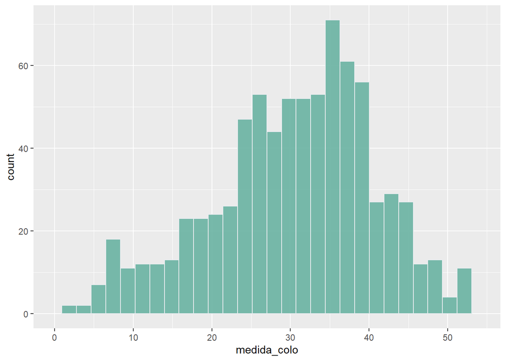

```r
ggplot(data = dados_obs2, aes(x = medida_colo)) +
  geom_histogram(fill = "#69b3a2",
                 color = "#e9ecef",
                 alpha = 0.9) +
  scale_x_continuous(limits = c(0, 54), breaks = seq(0, 54, 10)) +
  theme(plot.title = element_text(size = 15))
```

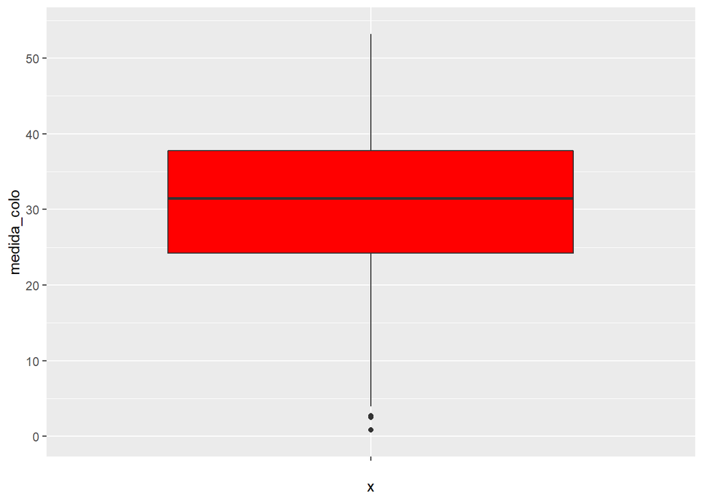

```r
ggplot(data = dados_obs2, aes(y = medida_colo, x = "")) +
  geom_boxplot(fill = "red") +
  scale_y_continuous(limits = c(0, 54), breaks = seq(0, 54, 10)) +
  theme(plot.title = element_text(size = 15))
```

## Imputação por regressão (modelo de regressão linear misto)

Vamos ajustar um modelo de regressão linear misto para medida do colo ao considerar os casos válidos (sem casos de NA para medida do colo) ao considerar como covariáveis IG aval, idade materna, cor_branco e imc (únicas variáveis fixas significativas).

```r
aj1 <- lme(medida_colo ~ ig_aval_sem + ovulos + corion + im + tescola + cor_branco + imc + gesta + ind_ap + hv_tabagismo + hv_alcool +  hv_drogas,
          random = ~ 1|id,
          data = dados_obs2, na.action = na.omit)
summary(aj1)
```

```
## Linear mixed-effects model fit by REML
##   Data: dados_obs2
##        AIC      BIC    logLik
##   5320.173 5403.832 -2642.087
##
## Random effects:
##  Formula: ~1 | id
##         (Intercept) Residual
## StdDev:    8.014645 4.953896
##
## Fixed effects:  medida_colo ~ ig_aval_sem + ovulos + corion + im + tescola +      cor_branco + imc + gesta + ind_ap + hv_tabagismo + hv_alcool +      hv_drogas
##                          Value Std.Error  DF    t-value p-value
## (Intercept)          16.424665  4.563439 520   3.599186  0.0003
## ig_aval_semsem27_28  -2.925139  0.519635 520  -5.629223  0.0000
## ig_aval_semsem29_30  -5.412485  0.566313 520  -9.557416  0.0000
## ig_aval_semsem31_32  -6.929753  0.648938 520 -10.678607  0.0000
## ig_aval_semsem33_34 -10.715069  0.581107 520 -18.439059  0.0000
## ovulosprogesterona   -1.356812  1.068401 251  -1.269947  0.2053
## coriondicoriônica    -0.440485  1.334957 251  -0.329962  0.7417
## im                    0.304809  0.099856 251   3.052478  0.0025
## tescola              -0.115451  0.245795 251  -0.469704  0.6390
## cor_brancosim         3.053746  1.099159 251   2.778258  0.0059
## imc                   0.416019  0.112589 251   3.695042  0.0003
## gesta                -0.293250  0.444553 251  -0.659652  0.5101
## ind_apsim             0.856253  1.257054 251   0.681159  0.4964
## hv_tabagismosim       0.153156  1.847916 251   0.082880  0.9340
## hv_alcoolsim          7.766038  5.472123 251   1.419200  0.1571
## hv_drogassim         -2.732988  5.322268 251  -0.513501  0.6081
##  Correlation:
##                     (Intr) i__27_ i__29_ i__31_ i__33_ ovlspr crndcr im
## ig_aval_semsem27_28 -0.069
## ig_aval_semsem29_30 -0.054  0.396
## ig_aval_semsem31_32 -0.042  0.332  0.302
## ig_aval_semsem33_34 -0.048  0.420  0.398  0.276
## ovulosprogesterona  -0.125  0.001  0.001  0.016 -0.019
## coriondicoriônica   -0.220  0.010  0.005  0.020 -0.009  0.106
## im                  -0.441  0.010 -0.011 -0.014 -0.005 -0.027  0.015
## tescola             -0.547  0.013  0.024 -0.007  0.017 -0.020 -0.030 -0.065
## cor_brancosim        0.000  0.001 -0.013  0.001 -0.008  0.000  0.098 -0.079
## imc                 -0.543  0.001 -0.002  0.012 -0.004  0.000 -0.036 -0.047
```

[output cut: 13 more lines]

```
## tescola
## cor_brancosim       -0.204
## imc                  0.000  0.001
## gesta                0.235  0.029 -0.144
## ind_apsim           -0.041 -0.003 -0.085 -0.180
## hv_tabagismosim      0.106  0.013  0.020 -0.041  0.026
## hv_alcoolsim         0.053  0.029  0.082 -0.049  0.092 -0.173
## hv_drogassim         0.050 -0.061  0.026 -0.010 -0.141 -0.022 -0.315
##
## Standardized Within-Group Residuals:
##          Min           Q1          Med           Q3          Max
## -5.319883541 -0.473736569 -0.007078719  0.469576813  3.258701910
##
## Number of Observations: 787
## Number of Groups: 263
```

```r
aj2 <- lme(medida_colo ~ ig_aval_sem +  im +  cor_branco + imc, random = ~ 1|id,
          data = dados_obs2, na.action = na.omit)
summary(aj2)
```

```
## Linear mixed-effects model fit by REML
##   Data: dados_obs2
##        AIC      BIC    logLik
##   5328.064 5374.644 -2654.032
##
## Random effects:
##  Formula: ~1 | id
##         (Intercept) Residual
## StdDev:    7.959795 4.953601
##
## Fixed effects:  medida_colo ~ ig_aval_sem + im + cor_branco + imc
##                          Value Std.Error  DF    t-value p-value
## (Intercept)          14.733479  3.497982 520   4.211994  0.0000
## ig_aval_semsem27_28  -2.920283  0.519441 520  -5.621970  0.0000
## ig_aval_semsem29_30  -5.401411  0.566028 520  -9.542661  0.0000
## ig_aval_semsem31_32  -6.903827  0.648441 520 -10.646804  0.0000
## ig_aval_semsem33_34 -10.725818  0.580606 520 -18.473497  0.0000
## im                    0.289667  0.087878 259   3.296244  0.0011
## cor_brancosim         2.910761  1.057278 259   2.753071  0.0063
## imc                   0.398352  0.109366 259   3.642367  0.0003
##  Correlation:
##                     (Intr) i__27_ i__29_ i__31_ i__33_ im     cr_brn
## ig_aval_semsem27_28 -0.079
## ig_aval_semsem29_30 -0.052  0.396
## ig_aval_semsem31_32 -0.056  0.332  0.302
## ig_aval_semsem33_34 -0.058  0.420  0.398  0.277
## im                  -0.586  0.014 -0.011 -0.012  0.000
## cor_brancosim       -0.136  0.003 -0.009 -0.002 -0.004 -0.062
## imc                 -0.679  0.003 -0.002  0.016 -0.002 -0.147  0.013
##
## Standardized Within-Group Residuals:
##        Min         Q1        Med         Q3        Max
## -5.3143484 -0.4819799 -0.0154134  0.4858558  3.2603420
##
## Number of Observations: 787
## Number of Groups: 263
```

```r
xnam <- c("ig_aval_sem", "im", "cor_branco", "imc")
fmla <- as.formula(paste("medida_colo ~ ", paste(xnam, collapse= "+"), paste("+ (1|id)",collapse= "+")))

aj <- lmer(fmla, data = dados_obs2, na.action = na.omit)
pred <- predict(aj, newdata = dados_obs2, re.form=NA)

dados_obs2 <- dados_obs2 %>%
  mutate(medida_colo_compl = ifelse(
    is.na(medida_colo), pred, medida_colo)
    )
```

Uma outra opção, ainda na linha de modelo de regressão, é considerar apenas a idade gestacional da avaliação.

```r
#só com ig aval
aja <- lme(medida_colo ~ ig_aval_sem, random = ~ 1|id,
          data = dados_obs2, na.action = na.omit)
summary(aja)
```

```
## Linear mixed-effects model fit by REML
##   Data: dados_obs2
##       AIC      BIC    logLik
##   5353.33 5385.963 -2669.665
##
## Random effects:
##  Formula: ~1 | id
##         (Intercept) Residual
## StdDev:    8.520593 4.955162
##
## Fixed effects:  medida_colo ~ ig_aval_sem
##                         Value Std.Error  DF   t-value p-value
## (Intercept)          34.52773 0.6299232 520  54.81261       0
## ig_aval_semsem27_28  -2.96236 0.5199818 520  -5.69705       0
## ig_aval_semsem29_30  -5.36745 0.5668955 520  -9.46815       0
## ig_aval_semsem31_32  -6.92510 0.6495442 520 -10.66148       0
## ig_aval_semsem33_34 -10.73492 0.5815578 520 -18.45890       0
##  Correlation:
##                     (Intr) i__27_ i__29_ i__31_
## ig_aval_semsem27_28 -0.370
## ig_aval_semsem29_30 -0.347  0.396
## ig_aval_semsem31_32 -0.292  0.331  0.301
## ig_aval_semsem33_34 -0.337  0.420  0.398  0.276
##
## Standardized Within-Group Residuals:
##          Min           Q1          Med           Q3          Max
## -5.133692037 -0.490694247 -0.001465759  0.457606743  3.429607309
##
## Number of Observations: 787
## Number of Groups: 263
```

```r
xnam1 <- c("ig_aval_sem")
fmla1 <- as.formula(paste("medida_colo ~ ", paste(xnam1, collapse= "+"), paste("+ (1|id)",collapse= "+")))

aj_soIG <- lmer(fmla1, data = dados_obs2, na.action = na.omit)
pred1 <- predict(aj_soIG, newdata = dados_obs2, re.form=NA)

dados_obs2 <- dados_obs2 %>%
  mutate(medida_colo_compl_soIG = ifelse(
    is.na(medida_colo), pred1, medida_colo)
    )
```

## Imputação por trajetória spline (pacote longitudinalData)

```r
dados_colo_traj <- as.matrix(dados_colo[,2:6]) #formato necessário para  função imputation

colo_imput_spline <- longitudinalData::imputation(dados_colo_traj,"spline",lowerBound=0.83,upperBound=54)

dados_colo1 <- dados_colo
dados_colo1[,2:6] <- colo_imput_spline

dados_colo_gather1 <- gather(data = dados_colo1, key ="ig_aval_sem", value = "medida_colo", "sem24_26", "sem27_28", "sem29_30", "sem31_32", "sem33_34")

dados_colo_gather1 <- dados_colo_gather1 %>%
  select(-ig_parto) %>%
  rename(medida_colo_imp = medida_colo)

dados_obs_novo <- full_join(dados_obs2, dados_colo_gather1, by= c("id", "ig_aval_sem"))

dados_obs_novo <- dados_obs_novo %>%
  arrange(id, ig_aval_sem)
```

# Imputação para número de contrações

Agora vamos realizar uma análise de dados faltantes para número de contrações.

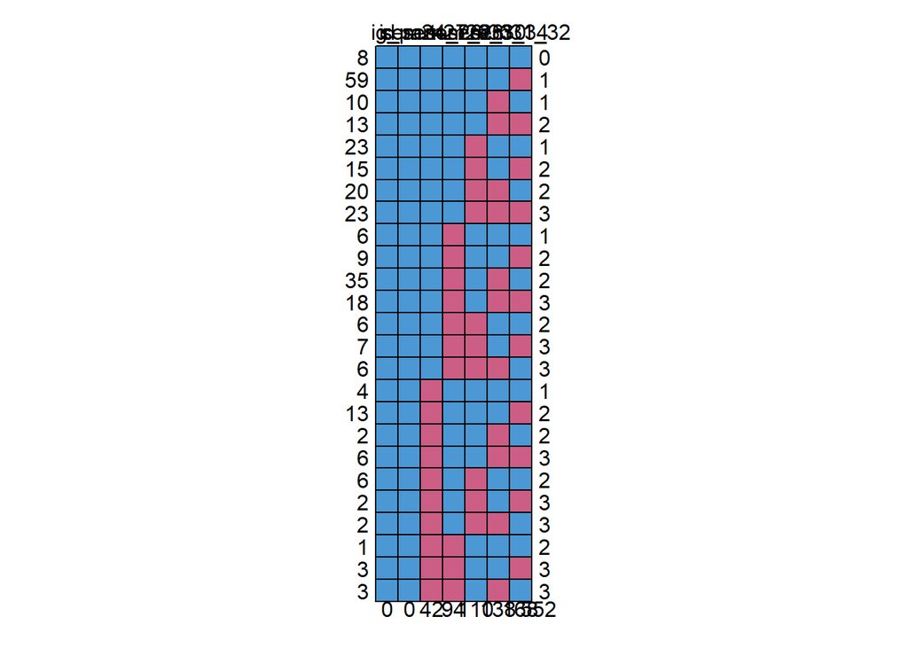

```
##    id ig_parto sem24_26 sem27_28 sem29_30 sem33_34 sem31_32
## 8   1        1        1        1        1        1        1   0
## 59  1        1        1        1        1        1        0   1
## 10  1        1        1        1        1        0        1   1
## 13  1        1        1        1        1        0        0   2
## 23  1        1        1        1        0        1        1   1
## 15  1        1        1        1        0        1        0   2
## 20  1        1        1        1        0        0        1   2
## 23  1        1        1        1        0        0        0   3
## 6   1        1        1        0        1        1        1   1
## 9   1        1        1        0        1        1        0   2
## 35  1        1        1        0        1        0        1   2
## 18  1        1        1        0        1        0        0   3
## 6   1        1        1        0        0        1        1   2
## 7   1        1        1        0        0        1        0   3
## 6   1        1        1        0        0        0        1   3
## 4   1        1        0        1        1        1        1   1
## 13  1        1        0        1        1        1        0   2
## 2   1        1        0        1        1        0        1   2
## 6   1        1        0        1        1        0        0   3
## 6   1        1        0        1        0        1        1   2
## 2   1        1        0        1        0        1        0   3
## 2   1        1        0        1        0        0        1   3
## 1   1        1        0        0        1        1        1   2
## 3   1        1        0        0        1        1        0   3
## 3   1        1        0        0        1        0        1   3
##     0        0       42       94      110      138      168 552
```

```r
md.pattern(dados_num_contra)
```

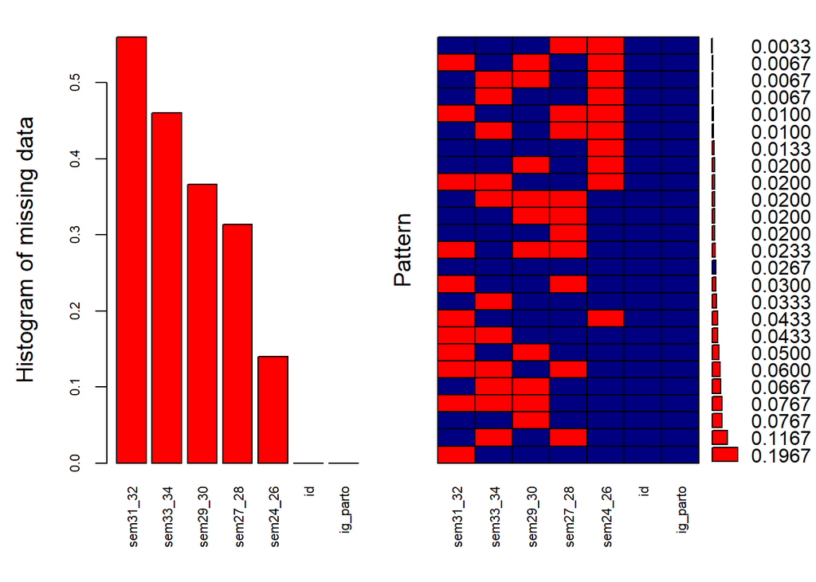

```
##
##  Variables sorted by number of missings:
##  Variable     Count
##  sem31_32 0.5600000
##  sem33_34 0.4600000
##  sem29_30 0.3666667
##  sem27_28 0.3133333
##  sem24_26 0.1400000
##        id 0.0000000
##  ig_parto 0.0000000
```

```r
aggr_plot <-
  aggr(
    dados_num_contra,
    col = c('navyblue', 'red'),
    numbers = TRUE,
    sortVars = TRUE,
    labels = names(dados_num_contra),
    cex.axis = .7,
    gap = 3,
    ylab = c("Histogram of missing data", "Pattern")
  )
```

```r
dados_contra_gather <- gather(data = dados_num_contra, key ="ig_aval_sem", value = "num_contra", "sem24_26", "sem27_28", "sem29_30", "sem31_32", "sem33_34")

dados_contra_gather <- dados_contra_gather %>%
  select(-ig_parto)

ids <- unique(dados_contra_gather$id)

#base só com as fixas soh com dados de pelo menos 2 avaliações do colo
dados_fixas_completo3 <- filter(dados_fixas_completo, id %in% ids)

dados_obs3 <- full_join(dados_fixas_completo3, dados_contra_gather, by= c("id"))

dados_obs3 <- dados_obs3 %>%
  arrange(id, ig_aval_sem)
```

Vamos ver a porcentagem de dados faltantes por idade gestacional:

```r
dados_obs3 %>%
  group_by(ig_aval_sem) %>%
  summarise(ncontra = sum(is.na(num_contra))/n()
            )
```

```
## # A tibble: 5 x 2
##   ig_aval_sem ncontra
##   <chr>         <dbl>
## 1 sem24_26      0.14
## 2 sem27_28      0.313
## 3 sem29_30      0.367
## 4 sem31_32      0.56
## 5 sem33_34      0.46
```

Antes do modelo, vamos ver o histograma e boxplot.

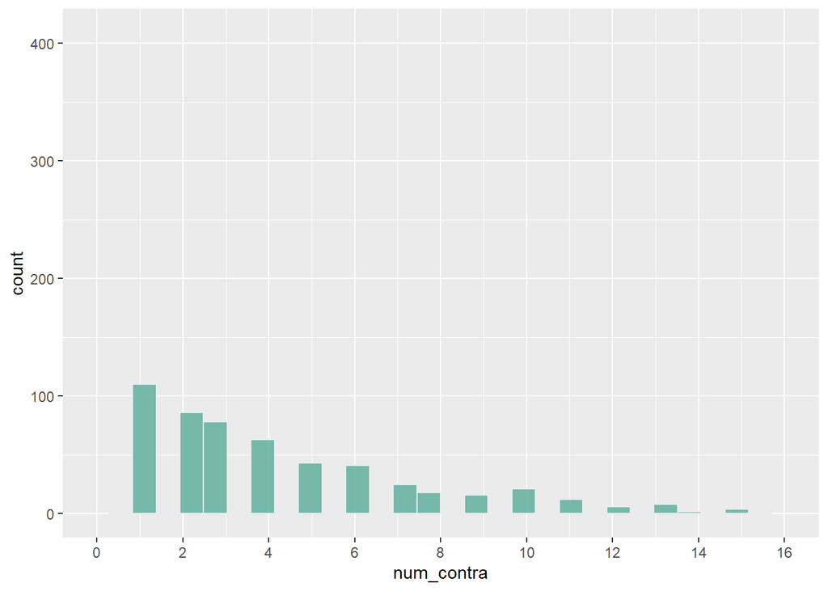

```r
ggplot(data = dados_obs3, aes(x = num_contra)) +
  geom_histogram(fill = "#69b3a2",
                 color = "#e9ecef",
                 alpha = 0.9) +
  scale_x_continuous(limits = c(0, 16), breaks = seq(0, 16, 2)) +
  theme(plot.title = element_text(size = 15))
```

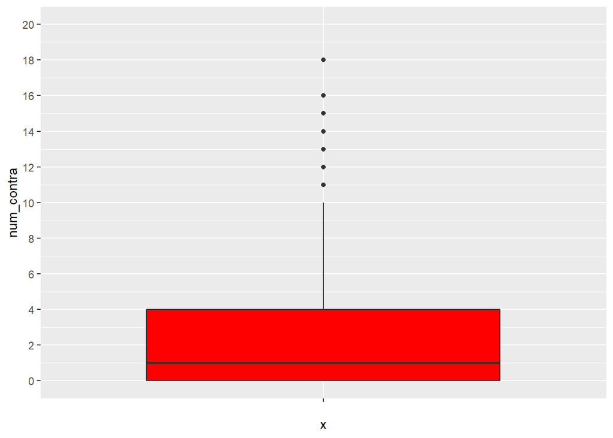

```r
ggplot(data = dados_obs3, aes(y = num_contra, x = "")) +
  geom_boxplot(fill = "red") +
  scale_y_continuous(limits = c(0, 20), breaks = seq(0, 20, 2)) +
  theme(plot.title = element_text(size = 15))
```

Vamos remover os outliers de número de contrações:

```r
dados_obs3 <- dados_obs3 %>%
  mutate(num_contra1 = ifelse(num_contra <= 10, num_contra, NA_integer_)
    )
```

## Imputação por regressão

Ao considerar o método https://cran.r-project.org/web/packages/glmmTMB/glmmTMB.pdf:

```r
nbm1 <- glmmTMB(num_contra1 ~ ig_aval_sem + ovulos + corion + im + tescola + cor_branco + imc + gesta + ind_ap + hv_tabagismo + hv_alcool +  hv_drogas + (1 | id), data = dados_obs3,
                family = nbinom2)

summary(nbm1)
```

```
##  Family: nbinom2  ( log )
## Formula:          num_contra1 ~ ig_aval_sem + ovulos + corion + im + tescola +
##     cor_branco + imc + gesta + ind_ap + hv_tabagismo + hv_alcool +
##     hv_drogas + (1 | id)
## Data: dados_obs3
##
##      AIC      BIC   logLik deviance df.resid
##   3368.3   3455.0  -1666.2   3332.3      894
##
## Random effects:
##
## Conditional model:
##  Groups Name        Variance Std.Dev.
##  id     (Intercept) 0.4137   0.6432
## Number of obs: 912, groups:  id, 300
##
## Overdispersion parameter for nbinom2 family (): 1.22
##
## Conditional model:
##                     Estimate Std. Error z value Pr(>|z|)
## (Intercept)          1.78903    0.51508   3.473 0.000514 ***
## ig_aval_semsem27_28  0.66073    0.13672   4.833 1.35e-06 ***
## ig_aval_semsem29_30  1.09078    0.13647   7.993 1.32e-15 ***
## ig_aval_semsem31_32  1.35715    0.14918   9.098  < 2e-16 ***
## ig_aval_semsem33_34  1.58903    0.14192  11.197  < 2e-16 ***
## ovulosprogesterona   0.04704    0.11659   0.403 0.686610
## coriondicoriônica   -0.11318    0.14416  -0.785 0.432382
## im                  -0.00824    0.01081  -0.762 0.445884
## tescola             -0.01182    0.02615  -0.452 0.651193
## cor_brancosim       -0.16647    0.12058  -1.381 0.167415
## imc                 -0.06147    0.01283  -4.791 1.66e-06 ***
## gesta               -0.04087    0.04733  -0.863 0.387918
## ind_apsim           -0.10943    0.13771  -0.795 0.426814
## hv_tabagismosim     -0.11773    0.20804  -0.566 0.571462
## hv_alcoolsim        -0.79168    0.67857  -1.167 0.243337
## hv_drogassim         0.93541    0.59673   1.568 0.116983
## ---
## Signif. codes:  0 '***' 0.001 '**' 0.01 '*' 0.05 '.' 0.1 ' ' 1
```

```r
nbm2 <- glmmTMB(num_contra1 ~ ig_aval_sem + ovulos + corion + im + tescola + cor_branco + imc  + (1 | id), data = dados_obs3,
                family = nbinom2)   #summary(nbm2)

nbm3 <- glmmTMB(num_contra1 ~ ig_aval_sem +  corion + im   + cor_branco + imc  + (1 | id), data = dados_obs3,
                family = nbinom2)  #summary(nbm3)

nbm4 <- glmmTMB(num_contra1 ~ ig_aval_sem +  im   + cor_branco + imc  + (1 | id), data = dados_obs3,
                family = nbinom2)   #summary(nbm4)

nbm5 <- glmmTMB(num_contra1 ~ ig_aval_sem + im + imc  + (1 | id), data = dados_obs3,
                family = nbinom2)
summary(nbm5)
```

```
##  Family: nbinom2  ( log )
## Formula:          num_contra1 ~ ig_aval_sem + im + imc + (1 | id)
## Data: dados_obs3
##
##      AIC      BIC   logLik deviance df.resid
##   3357.1   3400.4  -1669.5   3339.1      903
##
## Random effects:
##
## Conditional model:
##  Groups Name        Variance Std.Dev.
##  id     (Intercept) 0.4222   0.6498
## Number of obs: 912, groups:  id, 300
##
## Overdispersion parameter for nbinom2 family (): 1.21
##
## Conditional model:
##                      Estimate Std. Error z value Pr(>|z|)
## (Intercept)          1.657908   0.398865   4.157 3.23e-05 ***
## ig_aval_semsem27_28  0.661264   0.136855   4.832 1.35e-06 ***
## ig_aval_semsem29_30  1.083273   0.136488   7.937 2.08e-15 ***
## ig_aval_semsem31_32  1.351299   0.148832   9.079  < 2e-16 ***
## ig_aval_semsem33_34  1.595767   0.142089  11.231  < 2e-16 ***
## im                  -0.015294   0.009604  -1.592    0.111
## imc                 -0.064752   0.012545  -5.162 2.45e-07 ***
## ---
## Signif. codes:  0 '***' 0.001 '**' 0.01 '*' 0.05 '.' 0.1 ' ' 1
```

```r
nbm8 <- glmmTMB(num_contra1 ~ ig_aval_sem +  imc  + (1 | id), data = dados_obs3,
                family = nbinom2)
summary(nbm8)
```

```
##  Family: nbinom2  ( log )
## Formula:          num_contra1 ~ ig_aval_sem + imc + (1 | id)
## Data: dados_obs3
##
##      AIC      BIC   logLik deviance df.resid
##   3357.6   3396.1  -1670.8   3341.6      904
##
## Random effects:
##
## Conditional model:
##  Groups Name        Variance Std.Dev.
##  id     (Intercept) 0.4292   0.6551
## Number of obs: 912, groups:  id, 300
##
## Overdispersion parameter for nbinom2 family ():  1.2
##
## Conditional model:
##                     Estimate Std. Error z value Pr(>|z|)
## (Intercept)          1.28364    0.32413   3.960 7.49e-05 ***
## ig_aval_semsem27_28  0.67227    0.13690   4.911 9.08e-07 ***
## ig_aval_semsem29_30  1.08596    0.13675   7.941 2.00e-15 ***
## ig_aval_semsem31_32  1.34977    0.14916   9.049  < 2e-16 ***
## ig_aval_semsem33_34  1.60566    0.14219  11.293  < 2e-16 ***
## imc                 -0.06741    0.01251  -5.389 7.09e-08 ***
## ---
## Signif. codes:  0 '***' 0.001 '**' 0.01 '*' 0.05 '.' 0.1 ' ' 1
```

```r
pred_infl <- predict(nbm8,newdata = dados_obs3,  type ="response", re.form=NA)

#Só com IG aval como covar
nbm_soIG <- glmmTMB(num_contra1 ~ ig_aval_sem + (1 | id), data = dados_obs3, family = nbinom2)

summary(nbm_soIG)
```

```
##  Family: nbinom2  ( log )
## Formula:          num_contra1 ~ ig_aval_sem + (1 | id)
## Data: dados_obs3
##
##      AIC      BIC   logLik deviance df.resid
##   3384.1   3417.8  -1685.1   3370.1      905
##
## Random effects:
##
## Conditional model:
##  Groups Name        Variance Std.Dev.
##  id     (Intercept) 0.5237   0.7236
## Number of obs: 912, groups:  id, 300
##
## Overdispersion parameter for nbinom2 family (): 1.21
##
## Conditional model:
##                     Estimate Std. Error z value Pr(>|z|)
## (Intercept)          -0.4115     0.1142  -3.604 0.000313 ***
## ig_aval_semsem27_28   0.6765     0.1377   4.914 8.93e-07 ***
## ig_aval_semsem29_30   1.0874     0.1374   7.915 2.48e-15 ***
## ig_aval_semsem31_32   1.3735     0.1502   9.143  < 2e-16 ***
## ig_aval_semsem33_34   1.6026     0.1426  11.236  < 2e-16 ***
## ---
## Signif. codes:  0 '***' 0.001 '**' 0.01 '*' 0.05 '.' 0.1 ' ' 1
```

```r
pred_infl <- predict(nbm8,newdata = dados_obs3,  type ="response", re.form=NA)

dados_obs3 <- dados_obs3 %>%
  mutate(pred_infl = pred_infl
    )
```

```r
gm1 <- glmer(num_contra1 ~ ig_aval_sem +  imc +  (1 | id), data = dados_obs3, family = "poisson")

pred_glmer <- predict(gm1, newdata = dados_obs3,  type ="response", re.form=NA)

dados_obs3 <- dados_obs3 %>%
  mutate(pred_glmer = pred_glmer
  )
```

Vamos ver o resíduo:

```r
dados_obs3 <- dados_obs3 %>%
  mutate(res_infl = num_contra1 - pred_infl,
    res_glmer = num_contra1 - pred_glmer,
    res_infl_abs = abs(num_contra1 - pred_infl),
    res_glmer_abs = abs(num_contra1 - pred_glmer)
    )

summary(dados_obs3$res_glmer)
```

```
##    Min. 1st Qu.  Median    Mean 3rd Qu.    Max.    NA's
## -4.7170 -1.1572 -0.4887  0.4184  1.5162  9.3716     588
```

```r
summary(dados_obs3$res_infl)
```

```
##    Min. 1st Qu.  Median    Mean 3rd Qu.    Max.    NA's
## -5.9691 -1.2558 -0.5373  0.2404  1.2965  9.4245     588
```

```r
summary(dados_obs3$res_glmer_abs)
```

```
##    Min. 1st Qu.  Median    Mean 3rd Qu.    Max.    NA's
##  0.0017  0.6872  1.2630  1.8139  2.2593  9.3716     588
```

```r
summary(dados_obs3$res_infl_abs)
```

```
##    Min. 1st Qu.  Median    Mean 3rd Qu.    Max.    NA's
##  0.0021  0.6538  1.2724  1.8118  2.3374  9.4245     588
```

Acho que podemos ficar com nbm8. Os resíduos são similares e o glmer tem problema de convergência.

Agora vamos colocar as imputações para número de contrações por regressão.

```r
pred_contra <-
  predict(nbm8,
          newdata = dados_obs3,
          type = "response",
          re.form = NA)

pred_contra1 <-
  predict(nbm_soIG,
          newdata = dados_obs3,
          type = "response",
          re.form = NA)

dados_obs3 <- dados_obs3 %>%
  mutate(num_contra_compl = ifelse(
    is.na(num_contra1), pred_contra, num_contra),
    num_contra_compl_soIG = ifelse(
    is.na(num_contra1), pred_contra1, num_contra)
    )
```

Vamos também considerar o método de trajetória por splines:

## Imputação por trajetória spline (pacote longitudinalData)

```r
dados_num_contra_traj <- as.matrix(dados_num_contra[,2:6]) #formato necessário para  função imputation

dados_num_contra_traj <- ifelse(dados_num_contra_traj > 10, NA, dados_num_contra_traj)

contra_imput_spline <- longitudinalData::imputation(dados_num_contra_traj, "spline",lowerBound=0,upperBound=10)

dados_num_contra1 <- dados_num_contra
dados_num_contra1[,2:6] <- contra_imput_spline

dados_contra_gather1 <- gather(data = dados_num_contra1, key ="ig_aval_sem", value = "num_contra", "sem24_26", "sem27_28", "sem29_30", "sem31_32", "sem33_34")

dados_contra_gather1  <- dados_contra_gather1 %>%
  select(-ig_parto) %>%
  rename(num_contra_imp = num_contra)

dados_obs3 <- full_join(dados_obs3, dados_contra_gather1 , by= c("id", "ig_aval_sem"))

dados_obs3 <- dados_obs3 %>%
  arrange(id, ig_aval_sem)
```

## Concatenar as medidas

```r
#vamos ver se os dados válidos de medida do colo (dados_obs2) estão em num de contra (dados_obs3)
ids_numcontra <- unique(dados_obs3$id)
sum(!(dados_obs_novo$id %in% ids_numcontra))
```

```
## [1] 0
```

```r
dados_obs3_aux <- dados_obs3 %>%
  select(id, ig_aval_sem, num_contra, num_contra_compl, num_contra_compl_soIG, num_contra_imp)

dados_igs_completas <- inner_join(dados_obs_novo, dados_obs3_aux, by = c("id", "ig_aval_sem"))
# length(unique(dados_igs_completas$id))
# str(dados_igs_completas)
```

Pelo resultado acima, observamos que todos os casos que estão na base de dados de medida do colo estão também na base de dados válidos de número de contrações.

```r
write_xlsx(dados_igs_completas, "dados_igs_completas_5avals.xlsx")
```